# 5 - Export tracking results as video

Simon Garnier

## 0 - Introduction

Once you have finished tracking a video and fixing any potential error, you can use the `trackPlayer` app to create a nice, publication-ready video showing the results of the tracking overlaid over the frames. You can launch `trackPlayer` by typing the following command in the R console:

```r
trackPlayer()
```

## 1 - Data module

[figure not shown]

Once `trackPlayer` has started, it will open two windows: a display window that will later be used to display the video with the tracks overlaid on top (note: this window may be hiding behind other windows) and the window shown here that will display all the app controls.

The first step is to open the video and track files using the dedicated buttons in the control panel. Each button will open a navigator that you can use to find and select the video that was used during tracking and the CSV file that was produced either by `trackR` after tracking was completed or by `trackFixer` after fixing any potential tracking error.

## 2 - Play module

[figure not shown]

As soon as the video and track files are opened, `trackPlayer` will automatically switch to its “Play module” displayed in the image opposite and will show the video in the display window with the tracks overlaid (see image below).

At the top of the control panel, you will find the video controls that allow you to:

- Play and pause the video with the `Play/pause` button or with the space bar of your keyboard.
- Advance or rewind the video by 1 frame with the `>` and `<` buttons or with the right and left arrow keys of your keyboard.
- Advance or rewind the video by 1 second with the `>>` and `<<` buttons or with the up and down arrow keys of your keyboard.
- Move to any frame of the video with the slider below the video control buttons.

Below is a `Display size` control slider that allows you to change the size of the display window, for instance if the video is too wide for the screen. This does not affect the quality of the exported video.

Finally, at the bottom of the control panel is an `Export video` button that you can press in order to export an MP4 video showing the results of the tracking overlaid on top of the frame. This video should play well in all presentation programs (e.g. PowerPoint, Apple Keynote), on any website, and as supplementary material for your publications.

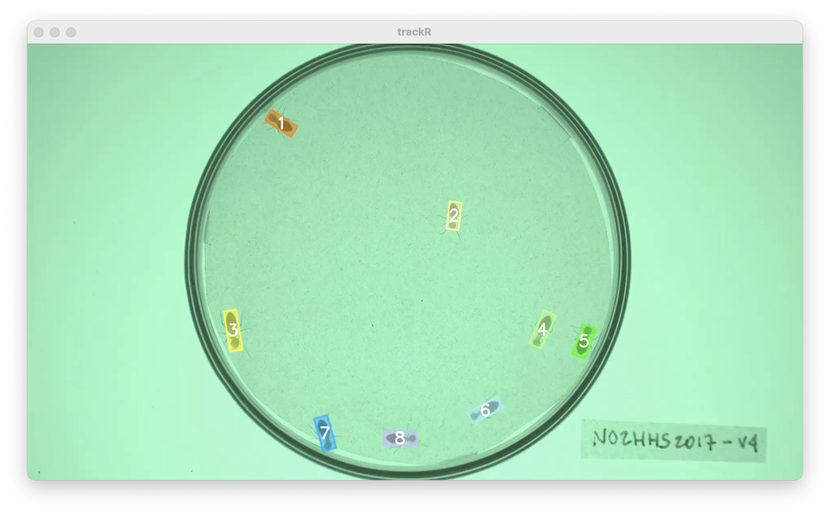

The video used throughout this tutorial was provided by *Sridhar, V. H., Roche, D. G., and Gingins, S. (2019). Tracktor: Image-based automated tracking of animal movement and behaviour. Methods Ecol. Evol. 10, 691. doi:10.1111/2041-210X.13166* and used here with permission of the authors.